# Insights into Digital Behavior by Aparnna Hariharan: Exploring Screen Time and Social Media Usage

The datasets I selected were sourced from online platforms focusing on digital habits and social media usage. One dataset delves into average screen time and usage by country in 2023, offering a broad view of global screen time trends. The other dataset explores social media behaviors, providing detailed insights into age groups, gender dynamics, preferred platforms, interests, and professions linked to screen time for social media interactions.

In my analysis, I aimed to uncover trends and patterns in screen time and social media usage across different groups. To address specific questions, I created the following visualizations:

1. **Global Trends in Screen Time**: A map graph illustrating soical media screen time between countries.
2. **Age Group and Platform Usage**: A stacked bar chart depicting screen time differences across age groups and social media platforms.
3. **Gender and Age Group Analysis**: A box plot showcasing variations in screen time among different age groups and genders.
4. **Correlation Between Social Media Use and Interests**: A heatmap revealing how social media usage correlates with various interests across different platforms.
5. **Screen Time Distribution Among Professions**: A histogram displaying the distribution of screen time across different professions.

Through these visuals, I gained insights into digital behavior and social media habits, allowing for a deeper understanding of how people interact with digital devices and social media platforms across diverse demographics.

References: Average Screen Time and Usage by Country 2023 https://www.kaggle.com/datasets/prasertk/average-screen-time-and-usage-by-country

Average Time Spent By A User On Social Media https://www.kaggle.com/datasets/imyjoshua/average-time-spent-by-a-user-on-social-media/data

```r
# Load required libraries
library(ggplot2)
library(maps)
library(rnaturalearth)
library(dplyr)
#install.packages("GGally")
library(GGally)
# install.packages("patchwork")
library(patchwork)
# Load the RColorBrewer package for color palette
library(RColorBrewer)
```

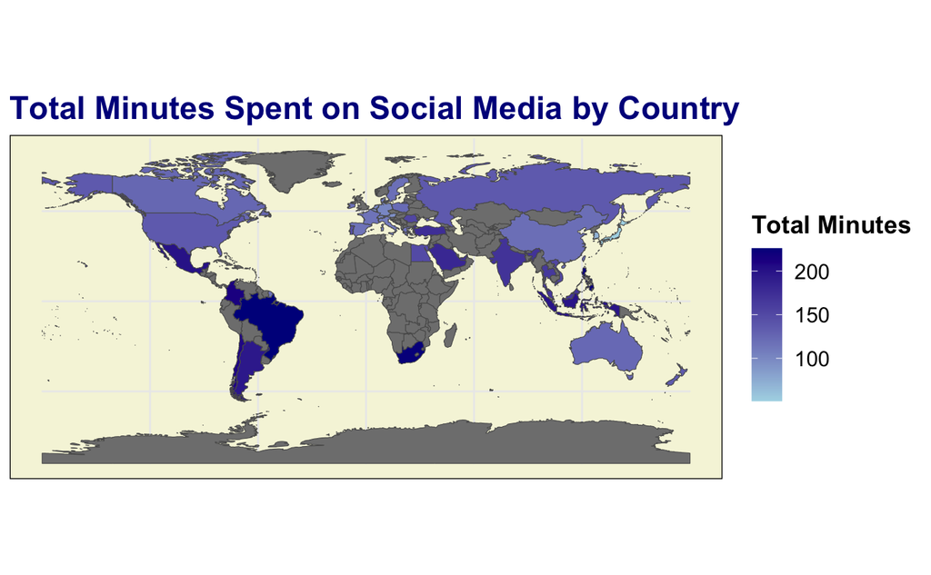

```r
dataset_country <- read.csv("average_sceen_time_by_country.csv")

# Convert time strings to hours
time_to_minutes <- function(time_str) {
  time_parts <- strsplit(time_str, ":")[[1]]
  hours <- as.numeric(time_parts[1])
  minutes <- as.numeric(time_parts[2])
  total_minutes <- hours * 60 + minutes
  return(total_minutes)
}

dataset_country$Time.Spent.using.Social.Media.minutes <- sapply(dataset_country$Time.Spent.using.Social.Media, time_to_minutes)

# Remove trailing spaces from country names in the dataset
dataset_country$Country <- trimws(dataset_country$Country)

# Check for values in dataset_country$Country not present in unique_country_names
world <- map_data("world")
unique_country_names <- unique(world$region)
not_in_map <- dataset_country$Country[!(dataset_country$Country %in% unique_country_names)]

#Rename countires
dataset_country$Country[dataset_country$Country == "U.A.E"] <- "United Arab Emirates"
dataset_country$Country[dataset_country$Country == "Czechia"] <- "Czech Republic"
dataset_country$Country[dataset_country$Country == "USA"] <- "United States of America"

# Retrieve world map data
world <- map_data("world")

# Merge your dataset with world map data
merged_data <- merge(world, dataset_country, by.x = "region", by.y = "Country", all.x = TRUE)

# Load world map data with higher resolution
world_highres <- ne_countries(scale = "medium", returnclass = "sf")

# Merge your dataset with the world map data
merged_data_highres <- merge(world_highres, dataset_country, by.x = "name", by.y = "Country", all.x = TRUE)

selected_data <- merged_data_highres[c("name", "Time.Spent.using.Social.Media.minutes")]

# Define custom theme for the map plot
custom_map_theme <- function() {
  theme_minimal() +
    theme(
      # Set plot title properties
      plot.title = element_text(size = 18, face = "bold", color = "darkblue"),
      # Set plot subtitle properties
      plot.subtitle = element_text(size = 16, face = "italic", color = "gray"),
      # Set legend title properties
      legend.title = element_text(size = 14, face = "bold"),
      # Set legend text properties
      legend.text = element_text(size = 12),
      # Set panel background color
      panel.background = element_rect(fill = "beige")
    )
}

# Create the map graph with custom theme
map_plot_highres <- ggplot() +
  geom_sf(data = merged_data_highres, aes(fill = Time.Spent.using.Social.Media.minutes)) +
  scale_fill_gradient(low = "lightblue", high = "darkblue", name = "Total Minutes") +
  labs(title = "Total Minutes Spent on Social Media by Country",
       fill = "Total Minutes") +
  custom_map_theme()  # Apply custom theme

# Display the map graph
print(map_plot_highres)
```

```r
dataset_social_media <- read.csv("average_time_on_social_media.csv")
dataset_social_media
```

| age | gender | time_spent | platform | interests | location | demographics | profession | income | indebt | isHomeOwner | Owns_Car |
| --- | --- | --- | --- | --- | --- | --- | --- | --- | --- | --- | --- |
| 56 | male | 3 | Instagram | Sports | United Kingdom | Urban | Software Engineer | 19774 | True | False | False |
| 46 | female | 2 | Facebook | Travel | United Kingdom | Urban | Student | 10564 | True | True | True |
| 32 | male | 8 | Instagram | Sports | Australia | Sub_Urban | Marketer Manager | 13258 | False | False | False |
| 60 | non-binary | 5 | Instagram | Travel | United Kingdom | Urban | Student | 12500 | False | True | False |
| 25 | male | 1 | Instagram | Lifestlye | Australia | Urban | Software Engineer | 14566 | False | True | True |
| 38 | male | 3 | Facebook | Travel | United States | Urban | Marketer Manager | 19179 | True | True | True |
| 56 | male | 8 | YouTube | Sports | United States | Urban | Student | 16881 | True | True | True |
| 36 | male | 4 | Instagram | Sports | Australia | Urban | Marketer Manager | 13636 | True | False | True |
| 40 | non-binary | 7 | YouTube | Lifestlye | Australia | Sub_Urban | Marketer Manager | 16030 | False | False | True |
| 28 | non-binary | 2 | Instagram | Sports | Australia | Sub_Urban | Marketer Manager | 10223 | True | False | True |

[output cut: 990 more lines]

```r
# Creating age groups
dataset_social_media <- dataset_social_media %>%
  mutate(age_group = cut(age,
                         breaks = c(18, 25, 30, 35, 40, 45, 50, 55, 60, 65),
                         labels = c("18-24", "25-29", "30-34", "35-39", "40-44",
                                    "45-49", "50-54", "55-59", "60-65"))) %>%
  na.omit()
```

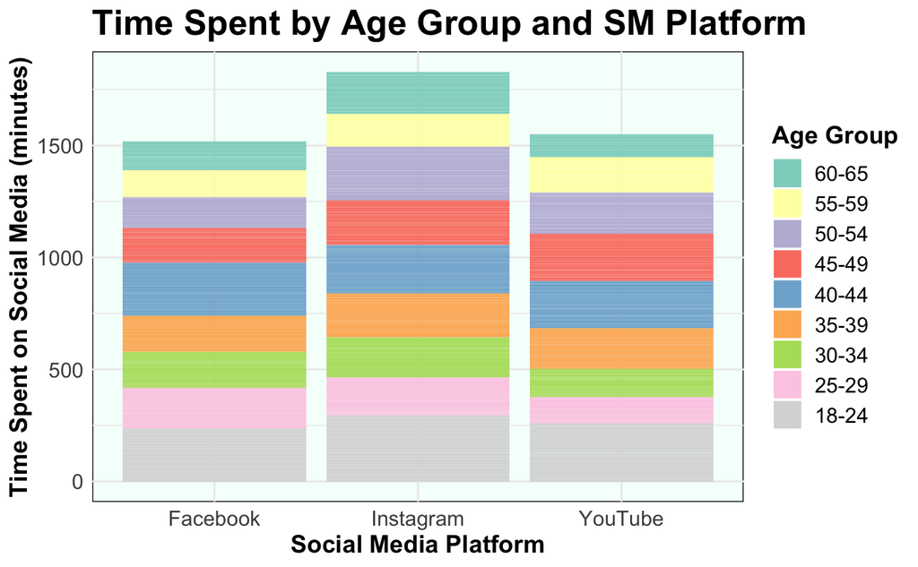

```r
# Define a color palette for age groups
age_group_colors <- brewer.pal(9, "Set3")

# Reorder age_group variable
dataset_social_media$age_group <- factor(dataset_social_media$age_group, levels = rev(levels(dataset_social_media$age_group)))

# Define custom theme for the stacked bar plot
custom_stacked_bar_theme <- function() {
  theme_minimal() +
    theme(
      # plot title properties
      plot.title = element_text(size = 20, face = "bold"),
      # axis label properties
      axis.title.x = element_text(size = 14, face = "bold"),
      axis.title.y = element_text(size = 14, face = "bold"),
      # axis text properties
      axis.text = element_text(size = 12),
      # panel background color
      panel.background = element_rect(fill = "mintcream"),
      # legend properties
      legend.title = element_text(size = 14, face = "bold"),
      legend.text = element_text(size = 12)
    )
}

# Create stacked bar plot with custom theme
stacked_bar_plot <- ggplot(dataset_social_media, aes(x = platform, y = time_spent, fill = age_group)) +
  geom_bar(stat = "identity", position = "stack") +  # Stacked bar plot with position = "stack"
  labs(title = "Time Spent by Age Group and SM Platform",
       x = "Social Media Platform",
       y = "Time Spent on Social Media (minutes)",
       fill = "Age Group") +
  scale_fill_manual(values = age_group_colors) +  # Use manual fill colors
  custom_stacked_bar_theme() +  # Apply custom theme
  guides(fill = guide_legend(title.position = "top"))  # Flip legend position

# Display the stacked bar plot
print(stacked_bar_plot)
```

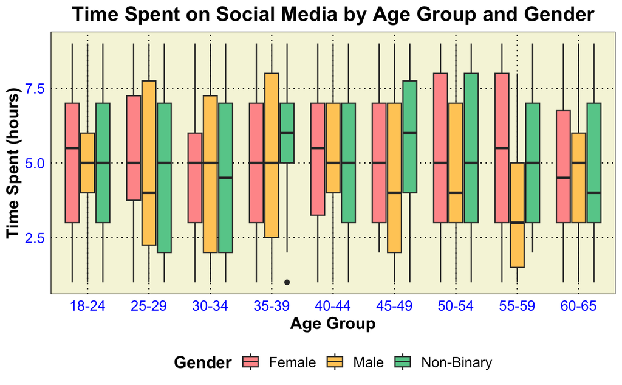

```r
# Filter out rows with NA values in the "age" column
filtered_data <- dataset_social_media %>%
  filter(!is.na(age))

# Define custom age intervals
age_intervals <- cut(filtered_data$age,
                      breaks = c(18, 25, 30, 35, 40, 45, 50, 55, 60, 65),
                      labels = c("18-24", "25-29", "30-34", "35-39", "40-44",
                                 "45-49", "50-54", "55-59", "60-65"))

# Filter out NA values from age_intervals
cleaned_age_intervals <- age_intervals[!is.na(filtered_data$age)]

# Assign the custom age intervals to dataset
filtered_data <- filtered_data %>%
  mutate(age_group = cleaned_age_intervals)

# Define custom theme for the box plot
custom_boxplot_theme <- function() {
  theme_minimal() +
    theme(
      # plot title properties
      plot.title = element_text(size = 17, face = "bold", hjust = 0.5),
      # axis label properties
      axis.title.x = element_text(size = 14, face = "bold"),
      axis.title.y = element_text(size = 14, face = "bold"),
      # axis text properties
      axis.text = element_text(size = 12, color = "blue"),
      # panel background color
      panel.background = element_rect(fill = "beige"),
      # Add gridlines
      panel.grid.major = element_line(color = "black", linetype = "dotted"),
      panel.grid.minor = element_blank(),
      legend.position = "bottom",
      legend.title = element_text(size = 14, face = "bold"),
      legend.text = element_text(size = 12)
    )
}

# Box plot of time spent on social media by age group and gender
boxplot_time_age_gender <- ggplot(filtered_data, aes(x = age_group, y = time_spent, fill = gender)) +
  geom_boxplot() +
  labs(title = "Time Spent on Social Media by Age Group and Gender",
       x = "Age Group", y = "Time Spent (hours)", fill = "Gender") +
  scale_fill_manual(values = c("#FF9999", "#FFCC66", "#66CC99", "#99CCFF", "#FF99CC", "#CCCCFF"),
                    labels = c("Female", "Male", "Non-Binary")) +  # Providing labels for gender
  custom_boxplot_theme()

# Print the box plot
print(boxplot_time_age_gender)
```

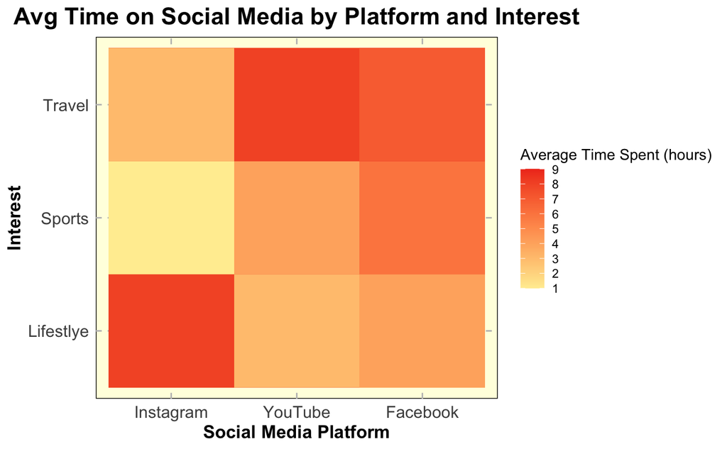

```r
# Create a custom color gradient function
custom_gradient <- colorRampPalette(c("#FFEDA0", "#F03B20"))

# Reorder levels of platform variable
dataset_social_media$platform <- factor(dataset_social_media$platform,
                                        levels = c("Instagram", "YouTube", "Facebook"))

# Determine breaks for the fill scale
breaks <- seq(1, 9, by = 1)  # Adjusted to match the data range

# Create a custom theme for the heatmap
custom_heatmap_theme <- function() {
  theme_minimal() +
    theme(
      # plot title properties
      plot.title = element_text(size = 17, face = "bold", hjust = 0.5),
      # axis label properties
      axis.title.x = element_text(size = 13, face = "bold"),
      axis.title.y = element_text(size = 13, face = "bold"),
      # axis text properties
      axis.text = element_text(size = 12),
      # panel background color
      panel.background = element_rect(fill = "lightyellow"),
      # Add gridlines
      panel.grid.major = element_line(color = "gray", linetype = "dashed"),
      panel.grid.minor = element_blank()
    )
}

# Create the heatmap with customized fill scale and custom theme
heatmap <- ggplot(dataset_social_media, aes(x = platform, y = interests, fill = time_spent)) +
  geom_tile() +
  scale_fill_gradient(name = "Average Time Spent (hours)",
                      breaks = breaks,
                      limits = c(min(breaks), max(breaks)),
                      low = custom_gradient(9)[1],  # Adjusted number of colors to match breaks
                      high = custom_gradient(9)[9],
                      na.value = "transparent") +  # Make NA values transparent
  labs(title = "Avg Time on Social Media by Platform and Interest",
       x = "Social Media Platform",
       y = "Interest") +
  custom_heatmap_theme() +  # Apply custom theme
  theme(axis.text.x = element_text(hjust = 0.5))  # Adjust x-axis text alignment

# Display the heatmap
print(heatmap)
```

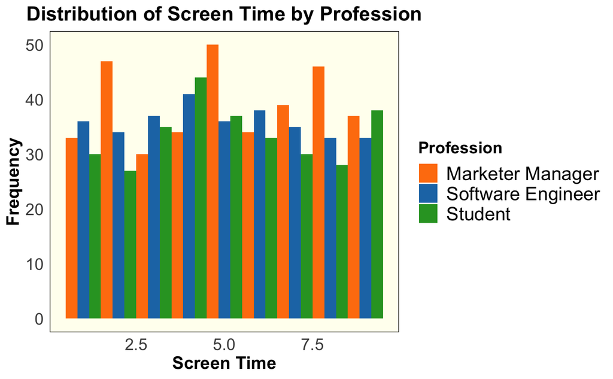

```r
# Define custom color palette for professions
profession_colors <- c("Software Engineer" = "#1f77b4",
                       "Marketer Manager" = "#ff7f0e",
                       "Student" = "#2ca02c")

# Define profession theme
custom_histogram_theme <- function() {
  theme_minimal() +
    theme(
      # plot title properties
      plot.title = element_text(size = 17, face = "bold",  hjust = 0.5),
      # axis label properties
      axis.title.x = element_text(size = 15, face = "bold"),
      axis.title.y = element_text(size = 15, face = "bold"),
      # legend title and label properties
      legend.title = element_text(size = 14, face = "bold"),
      legend.text = element_text(size = 16),
      # axis text properties
      axis.text = element_text(size = 14),
      # panel background color
      panel.background = element_rect(fill = "ivory"),
      # Remove gridlines
      panel.grid.major = element_blank(),
      panel.grid.minor = element_blank()
    )
}

# Create a histogram for each profession using custom color and theme
histogram <- ggplot(dataset_social_media, aes(x = time_spent, fill = profession)) +
  geom_histogram(binwidth = 1, position = "dodge") +
  labs(title = "Distribution of Screen Time by Profession",
       x = "Screen Time",
       y = "Frequency") +
  scale_fill_manual(values = profession_colors, name = "Profession") +
  custom_histogram_theme()

# Display the histogram
print(histogram)
```